# Report

2024-05-13

# What Makes a Successful Journal Article?

*`Lisa Florentina Scherrer`*

Data Mining For Political and Social Science in R

[figure not shown]

## 2 Hypotheses

The parameter for a successful article and dependent variable is the amount of references. The university is a young institution not having published studies with “cult status”, the first Hypothesis (H1) is that there are very few highly cited articles. However, these articles can gain acclaim through discussing current topics, therefore recent publications are more popular (H2). The language of the article also plays a role due to the increasing importance of English, that is why English publications are cited more often than other papers (H3) and the share of English publications has increased (H4). Lastly, articles that are of an interdisciplinary nature are relevant to more research fields and yield better results and regardless of the few study programms offered the publishers are diverse (H5).

## 3 Retrieving Data

### 3.1 GET Request

To access data related to journal articles the REST API by Crossref was used. To establish the connection a GET request was made. In the case of this API it is only possible to request 1000 journal articles per request made.

In order to automate the process of making several requests a loop was created. However, it was not possible to access more than 10000 articles in total. This was only discovered later when looking at the contents of the data and found the last request information to be empty. To avoid the for loop running until the total of 276 000 journal article data was retrieved an if condition was implemented. When the infomation contains less then 10 000 characters the loop stops and the following empty information is not requested.

### 3.2 Saving and Transforming

Additionally, the data should be saved immediately after every request. In the case of this data set it was not possible to use *write.csv()* since the information was not two dimensional. The author column for instance contained further lists detailing the different authors and further the institutions they were affiliated with. That is why the data was saved with *save()* to create a file in .Rda format.

Since the data had to be requested multiple times these seperate responses were joined into one file. For this purpose a Loop was created to merge these data frames together as df_journal. The data was saved in a .Rda file format again because of the complexity of the data.

## 4 Analysis and Visualisation

### 4.1 Reference Count

*Figure 1* and *Figure 2* represent the distribution of the reference counts of the articles, while all articles with reference count NA were removed. It is apparent that there is a strong tendency for articles to have very few citations as previously hypothesised (H1).

[figure not shown]

Figure 1

As visible in *Figure 2* the papers quoted 0-5 exceed 5000 and represent more than half of the sample.

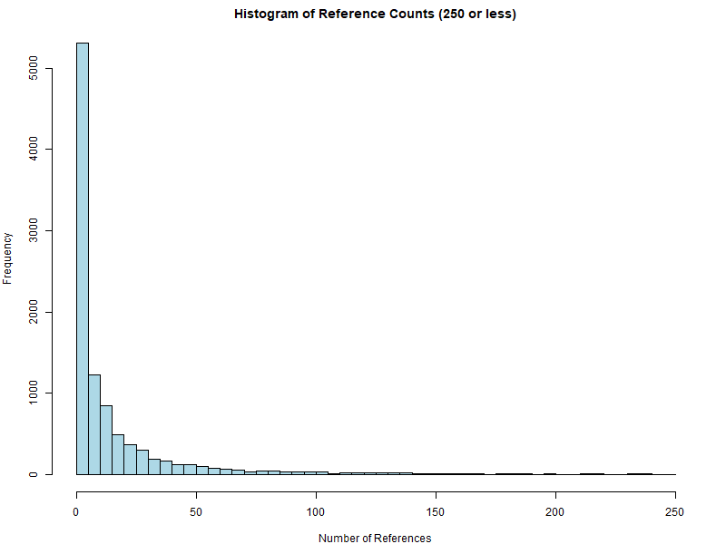

Figure 2

### 4.2 Timeline

To analyse a possible corralation between the year the articles were written and their citation count these two variables were plotted against each other in *Figure 3.* In the scatter plot there does not seem to be a visible connection between the two variables, therefore not fulfilling the requirements for further analysis with a regression model and disproving H2.

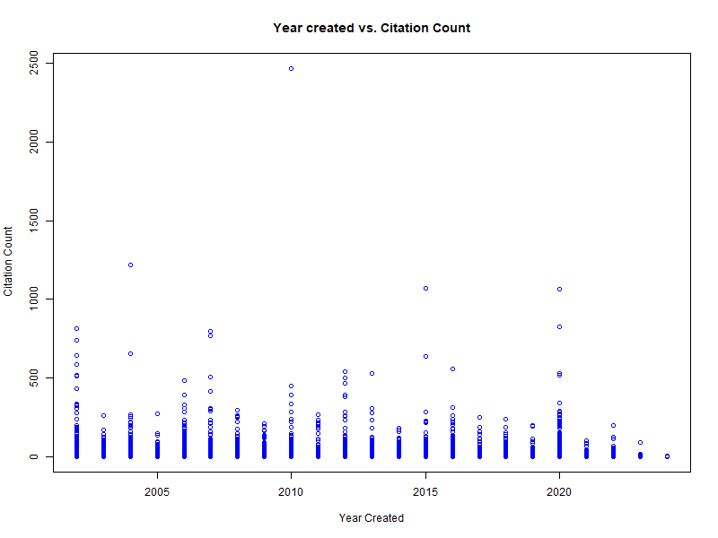

Figure 3

### 4.3 Language

Regarding the language of publication there is a clear trend in terms of citation count. As previously hypothesised the articles written in English are cited significantly more frequently than other languages as depicted in *Figure 4* and therefore supports H3.

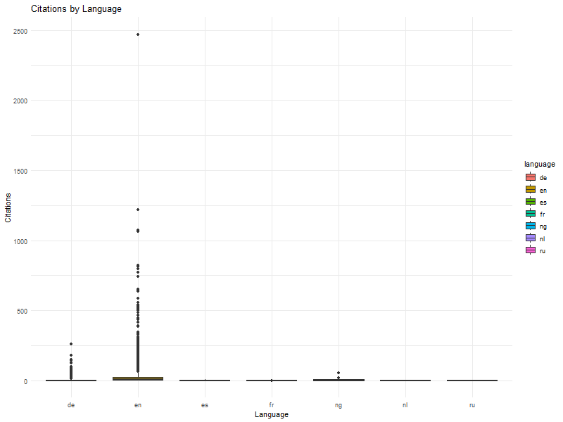

Figure 4

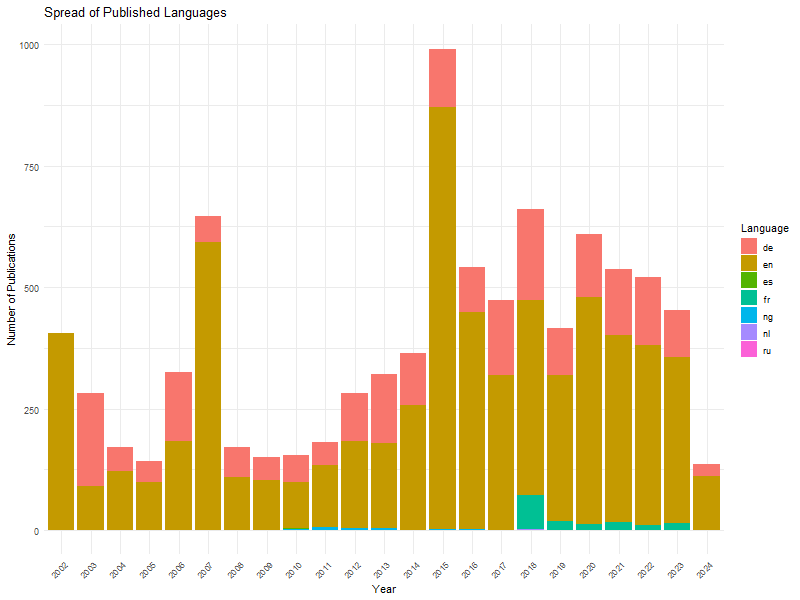

Figure 5

### 4.4 Publisher

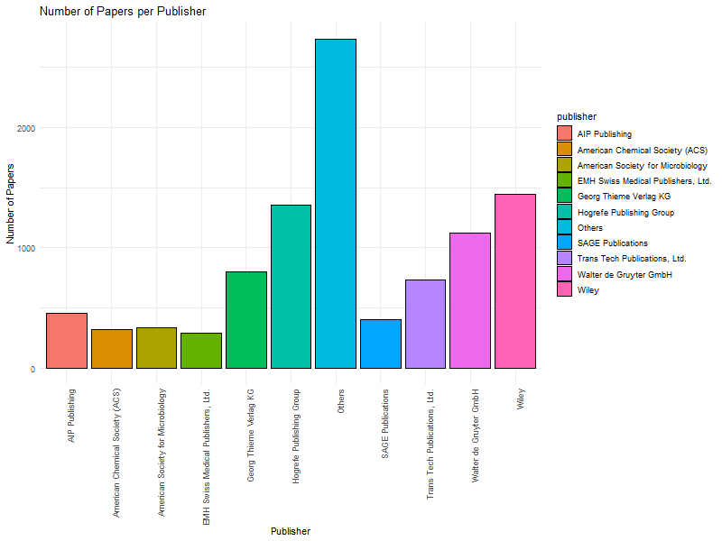

Figure 6

## 5 Conclusion

### 5.2 Limitations

This report was insightful in many aspects suggesting that most of our Hypotheses could be correct. Nevertheless, the sample is quite small with 10 000 journal articles and might not be representative of the actual trends concerning the metadata of these publications. Additionally, there need to be more investigations made on each of the Hypotheses to confirm or suggest a strong link between the variables.